# Comparative Genomics Southern Flounder

```r
knitr::opts_chunk$set(warning = FALSE, message = FALSE)
Mode <- function(x) {
  ux <- unique(x)
  ux[which.max(tabulate(match(x, ux)))]
}
source("lib/libraries.R")
source("lib/ggplot.R")
source("lib/VCFfilterstats.R")
source("lib/HaplotypR.R")
```

# Read Mapping

Map each library to optimized *de novo* reference by transfering copy of `reference.fasta` and associated files for K1 = 2 and K2 = 1 into each directory containing demultiplexed and quality trimmed `fastq`-files.

```
cd /home/soleary/FLOUNDER/REF/REF21
cp reference.fasta* /home/soleary/FLOUNDER/SEQUENCES/SFL-1
cp reference.fasta* /home/soleary/FLOUNDER/SEQUENCES/SFL-FamB
```

Run `dDocent` from within each library directory to map reads to `reference.fasta`. Change mapping parameters for BWA to:

- Mapping Match_Value: 1
- Mapping Mismatch_Value: 3
- Mapping GapOpen_Penalty: 5

Run dDocent separately for each mapping family:

```
cd /home/soleary/FLOUNDER/SEQUENCES/SFL-1
dDocent

cd /home/soleary/FLOUNDER/SEQUENCES/SFL-FamB
dDocent
```

# Variant Calling

Call SNPs for each mapping family separately.

```
cd /home/soleary/FLOUNDER/SEQUENCES/SFL-1
dDocent

cd /home/soleary/FLOUNDER/SEQUENCES/SFL-FamB
dDocent
```

File `TotalRawSNPs.vcf` contains all raw SNP/INDEL calls.

# SNP Filtering

Filter and haplotyping resulting SNP data sets separately for Fam-A and Fam-B.

Bash script `scr/other/VCF_Filtering.sh` contains commands to use `vcftools` to run through a variety of options and combinations of threshold values for quality, allowed missing data, minor alleles etc. The number of SNPs and individuals retained at each step is recorded in the spreadsheet `data/VCF/FilterStats.xls` to help select appropriate filtering steps and final threshold values.

## Family A

For *Family-A* HiSeq data mapped to MiSeq reference generated using all individuals in library.

### Prepare SNP data set for filtering

dDocent uses FreeBayes to call SNPs and write a VCF-file `TotalRawSNPs.vcf`. This data set was filtered to remove low quality and artefactual SNP sites, paralogs and low quality individuals based on levels of missing data, minimum/maximum read depth, genotype call rate, and minor allele frequencies. Contigs may contain more than one SNP; the script `rad_haplotyper.pl` was used to create haplotypes for each locus.

Generate a list of all individuals included in the SNP data set called by FreeBayes in the dDocent pipeline.

```
cd /home/soleary/FLOUNDER/SEQUENCES/SFL-1
vcfsamplenames TotalRawSNPs.vcf > Ind_RAW
```

Use `VCFtools` to create stats files for depth, missing data, heterozygosity and site quality for the raw data.

```
vcftools --vcf TotalRawSNPs.vcf --out FamA_raw --depth
vcftools --vcf TotalRawSNPs.vcf --out FamA_raw --site-mean-depth
vcftools --vcf TotalRawSNPs.vcf --out FamA_raw --site-quality
vcftools --vcf TotalRawSNPs.vcf --out FamA_raw --missing-indv
vcftools --vcf TotalRawSNPs.vcf --out FamA_raw --missing-site
vcftools --vcf TotalRawSNPs.vcf --out FamA_raw --het
```

Identify low quality individuals by comparing levels of missing data and read depth.

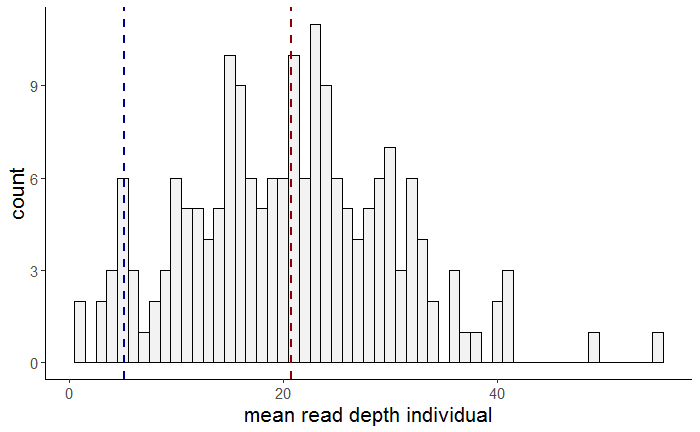

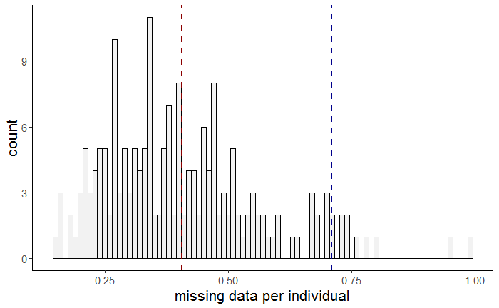

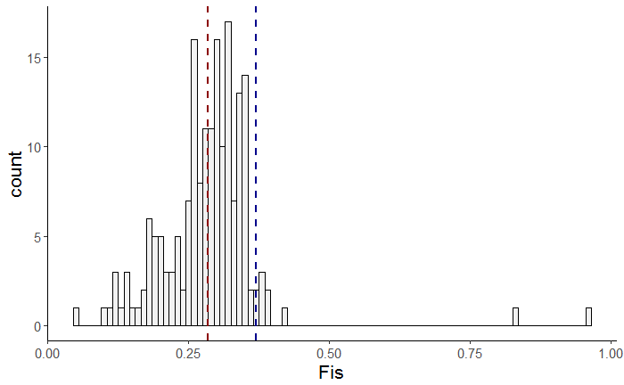

### Choose threshold values for quality score, coverage, missing data, minor alleles

#### Filter 0: Sequence quality

The QUAL column of a VCF file is a phred based score indicating the probability that the variant shown in the ALT column is wrong. Given the Phred quality score (Q), and the probability that a base is incorrectly called (P), Q = -10(Log10P).

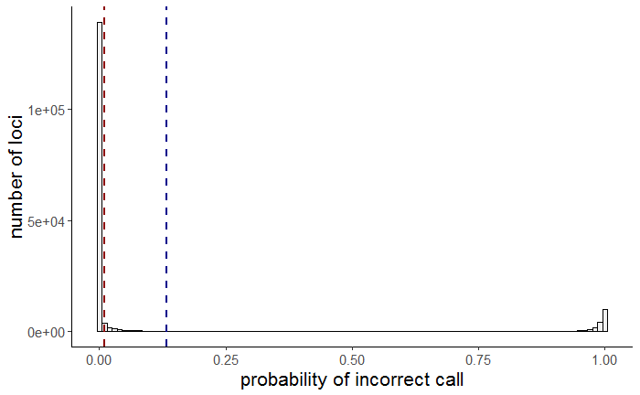

A quality score of 20 indicates, a 1 in 100 chance that the SNP site has been called incorrectly (i.e. 99% probability that correct call).

| QUAL < 20 | n |
| --- | --- |
| FALSE | 141881 |
| TRUE | 36763 |

Filter loci with quality score < 20:

```
vcftools --vcf TotalRawSNPs.vcf --out FamA.F0 --minQ 20 --recode --recode-INFO-all
```

#### Filter 1: genotype call rate & minimum minor allele count

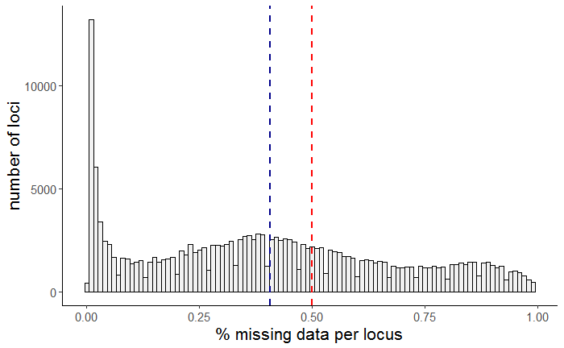

| MISS_FamA_raw > 0.5 | n |
| --- | --- |
| FALSE | 114851 |
| TRUE | 63793 |

Filter loci with minor allele count < 3 and genotype call rate < 0.5

```
vcftools --vcf FamA.F0.recode.vcf --out FamA.F1 --max-missing 0.5 --mac 3 --recode --recode-INFO-all
```

#### Filter 2: minimum depth per genotype

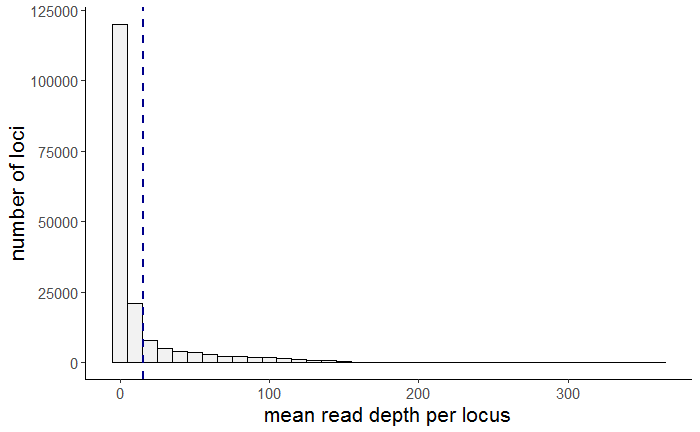

Code loci with less than 3 reads per locus per individual as missing.

```
vcftools --vcf FamA.F1.recode.vcf --out FamA.F2a --minDP 3 --recode --recode-INFO-all
```

Remove flagged loci.

```
vcftools --vcf FamA.F2a.recode.vcf --out FamA.F2  --max-missing 0.5 --recode --recode-INFO-all
```

Query individual and site stats:

```
vcftools --vcf FamA.F2.recode.vcf --out FamA.F2 --depth
vcftools --vcf FamA.F2.recode.vcf --out FamA.F2 --site-mean-depth
vcftools --vcf FamA.F2.recode.vcf --out FamA.F2 --site-quality
vcftools --vcf FamA.F2.recode.vcf --out FamA.F2 --missing-site
vcftools --vcf FamA.F2.recode.vcf --out FamA.F2 --missing-indv
vcftools --vcf FamA.F2.recode.vcf --out FamA.F2 --het
```

Assess individual quality by comparing levels of missing data and read depth.

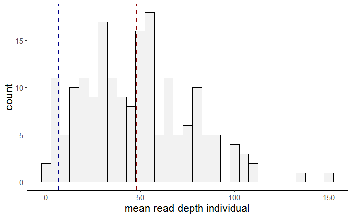

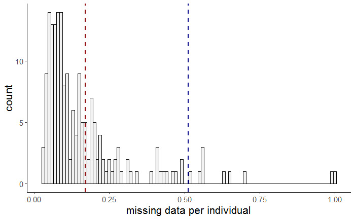

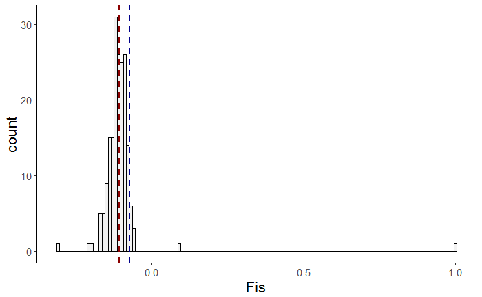

#### Filter 3: missing data (locus/indv) I

Filter loci with genotype call rate < 0.6

```
vcftools --vcf FamA.F2.recode.vcf --out FamA.F3a --max-missing 0.6 --recode --recode-INFO-all
vcftools --vcf FamA.F3a.recode.vcf --out FamA.F3a --missing-indv
```

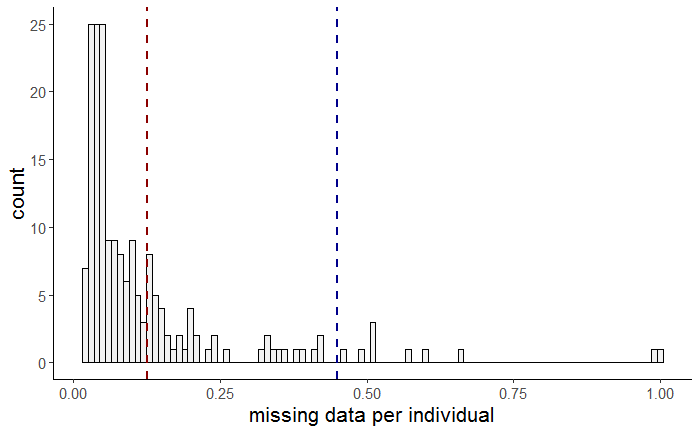

Remove individuals with more than 90% missing data

```
mawk -v x=0.9 '$5 > x' FamA.F3a.imiss | cut -f1 > lowDP.indv
vcftools --vcf FamA.F3a.recode.vcf --remove lowDP.indv --out FamA.F3b --recode --recode-INFO-all
```

#### Filter 4: minor allele frequency, mean minimum depth I

Remove loci with minor allele frequency < 0.01 and mean minimum depth (across all individuals) < 5

```
vcftools --vcf FamA.F3b.recode.vcf --out FamA.F4 --maf 0.01 --min-meanDP 5 --recode --recode-INFO-all
vcftools --vcf FamA.F4.recode.vcf --out FamA.F4 --missing-indv
vcftools --vcf FamA.F4.recode.vcf --out FamA.F4 --missing-site
vcftools --vcf FamA.F4.recode.vcf --out FamA.F4 --depth
vcftools --vcf FamA.F4.recode.vcf --out FamA.F4 --het
```

Assess individual quality by comparing levels of missing data and read depth.

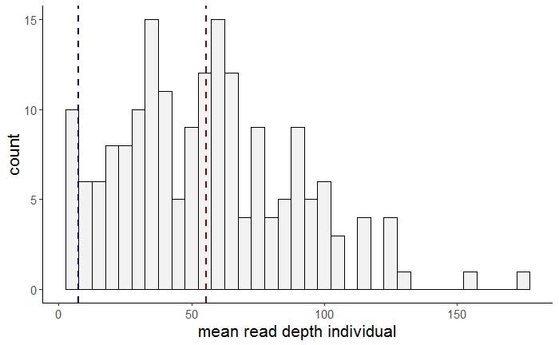

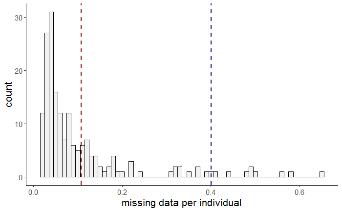

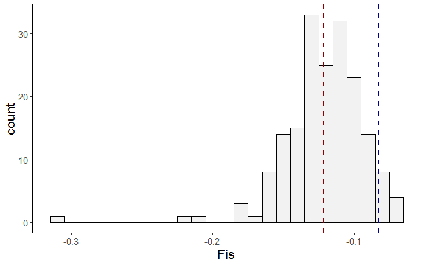

#### Filter 5: missing data (locus/indv) II

Remove loci with genotype call rate < 0.8

```
vcftools --vcf FamA.F4.recode.vcf --out FamA.F5a --max-missing 0.8  --recode --recode-INFO-all
vcftools --vcf FamA.F5a.recode.vcf --out FamA.F5a --missing-indv
```

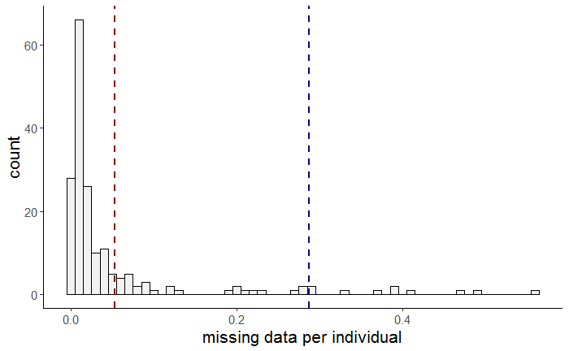

Remove individuals with > 75% missing data

```
mawk -v x=0.75 '$5 > x' FamA.F5a.imiss | cut -f1 > lowDP.indv
vcftools --vcf FamA.F5a.recode.vcf --remove lowDP.indv --recode --recode-INFO-all --out FamA.F5b
```

#### Filter 6: minor allele frequency, mean minimum depth II

```
vcftools --vcf FamA.F5b.recode.vcf --out FamA.F6 --maf 0.03 --recode --recode-INFO-all
vcftools --vcf FamA.F6.recode.vcf --out FamA.F6 --min-meanDP 10
vcftools --vcf FamA.F6.recode.vcf --out FamA.F6 --missing
vcftools --vcf FamA.F6.recode.vcf --out FamA.F6 --depth
vcftools --vcf FamA.F6.recode.vcf --out FamA.F6 --het
vcftools --vcf FamA.F6.recode.vcf --out FamA.F6 --missing-indv
vcftools --vcf FamA.F6.recode.vcf --out FamA.F6 --missing-site
```

Assess individual quality by comparing levels of missing data and read depth.

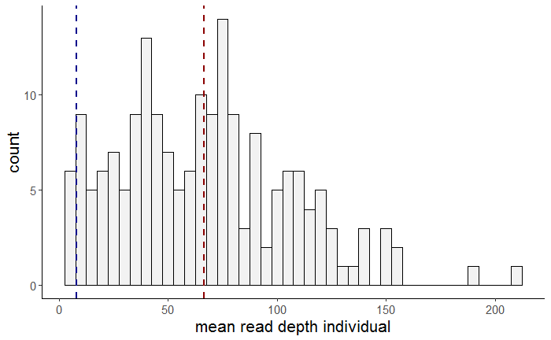

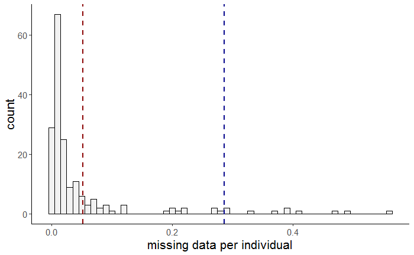

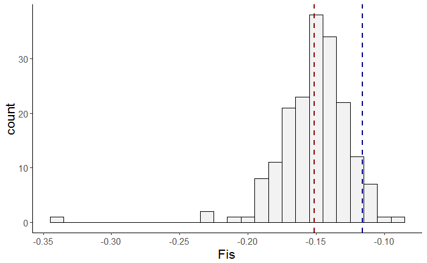

#### Filter 7: missing data (locus/indv) III

```
vcftools --vcf FamA.F6.recode.vcf --out FamA.F7a --max-missing 0.85 --recode --recode-INFO-all
vcftools --vcf FamA.F7a.recode.vcf --out FamA.F7a --missing-indv
```

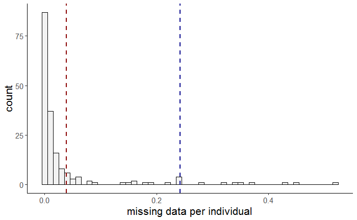

Remove individuals with > 65% missing data.

```
mawk -v x=0.65 '$5 > x' FamA.F7a.imiss | cut -f1 > lowDP.indv
vcftools --vcf FamA.F7a.recode.vcf --remove lowDP.indv --recode --recode-INFO-all --out FamA.F7b
```

#### Filter 8: Ratios of reference/alternate alleles, quality/depth, and mapping quality

```
vcffilter -s -f "AB > 0.2 & AB < 0.8 | AB < 0.01 | AB > 0.99" -s -g "QR > 0 | QA > 0" FamA.F7b.recode.vcf > FamA.F8a.vcf
```

Remove loci with quality/depth ratio < 0.2

```
vcffilter -s -f "QUAL / DP > 0.2" FamA.F8a.vcf > FamA.F8b.vcf
```

Remove loci based on ratio of mapping quality for reference and alternate allele, i.e. sites that have a high discrepancy between the mapping qualities of two alleles.

```
vcffilter -s -f "MQM / MQMR > 0.25 & MQM / MQMR < 1.75" FamA.F8b.vcf > FamA.F8c.vcf
```

Compare number of loci pre/post-filtering

```
mawk '!/#/' FamA.F7b.recode.vcf | wc -l
mawk '!/#/' FamA.F8a.vcf | wc -l
mawk '!/#/' FamA.F8b.vcf | wc -l
mawk '!/#/' FamA.F8c.vcf | wc -l
```

#### Filter 9: Loci with reads from both strands

```
vcffilter -f "SAF / SAR > 100 & SRF / SRR > 100 | SAR / SAF > 100 & SRR / SRF > 50" -s FamA.F8c.vcf > FamA.F9.vcf
```

Compare number of loci pre/post-filtering

```
mawk '!/#/' FamA.F9.vcf | wc -l
```

#### Filter 10: Properly paired status

Identify loci that only unpaired reads mapping to them - an artifact introduced due de novo reference assembly. Compare number of paired reads mapping the reference and the alternate alleles to identify discrepancy in the paired status for reads supporting reference and alternate alleles.

```
vcffilter -f "PAIRED > 0.05 & PAIREDR > 0.05 & PAIREDR / PAIRED < 1.75 & PAIREDR / PAIRED > 0.25 | PAIRED < 0.05 & PAIREDR < 0.05" -s FamA.F9.vcf > FamA.F10.vcf
```

Compare number of loci rep/post-filtering

```
mawk '!/#/' FamA.F10.vcf | wc -l
```

#### Filter 11: Maximum depth

Estimate the original number of individuals in the VCF file (INFO flags in filtered data set are are based on original number of individuals in data set):

```
grep -o -e 'NS=[0-9]*' FamA.F10.vcf | sed s/NS=//g | sort | tail -1
```

Create file with the original site depth and quality score for each site:

```
cut -f8 FamA.F10.vcf | grep -oe "DP=[0-9]*" | sed -s 's/DP=//g' > FamA.F10.DEPTH
mawk '!/#/'  FamA.F10.vcf | cut -f1,2,6 > FamA.F10.loci.qual
```

Calculate average depth and standard deviation:

```
mawk '{ sum += $1; n++ } END { if (n > 0) print sum / n; }' FamA.F10.DEPTH

mawk '{delta = $1 - avg; avg += delta / NR; mean2 += delta * ($1 - avg); } END { print sqrt(mean2 / NR); }' FamA.F10.DEPTH
```

```
paste FamA.F10.loci.qual FamA.F10.DEPTH | mawk -v x=21187.41 '$4 > x'| mawk '$3 < 2 * $4' > FamA.F10.lowQDloci
```

```
vcftools --vcf FamA.F10.vcf --remove-filtered NP --exclude-positions FamA.F10.lowQDloci --site-depth --out FamA.F10
cut -f3 FamA.F10.ldepth > FamA.F10.site.depth
mawk '!/D/' FamA.F10.site.depth | mawk -v x=185 '{print $1/x}' > FamA.meandepthpersite
```

Compare the distribution of mean depth per site averaged across individuals to determine cut-off value of sites with excessively high depth indicative of paralogs/multicopy loci.

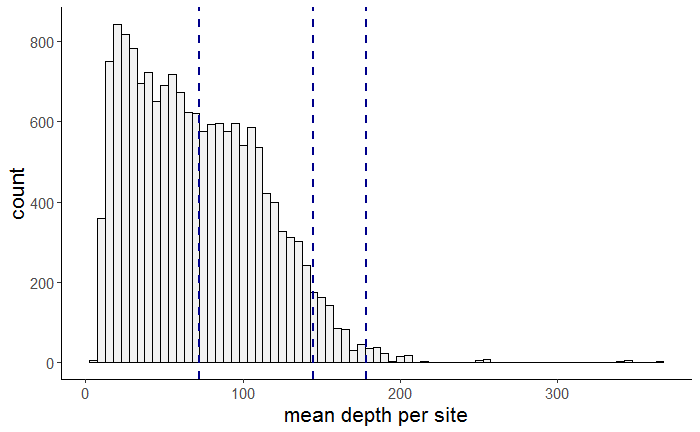

Choose cut-off value = 250. Combine both depth filters to produce filtered data set.

```
vcftools --vcf  FamA.F10.vcf --max-meanDP 250 --exclude-positions FamA.F10.lowQDloci --recode --recode-INFO-all --out FamA.F11
```

#### Filter 12: Remove Indels

Remove Indels from data set.

```
vcfallelicprimitives FamA.F11.recode.vcf --keep-info --keep-geno > FamA.prim.vcf
vcftools --vcf FamA.prim.vcf --out FamA.F12 --remove-indels --recode --recode-INFO-all
```

#### Filter 13: Minor allele frequency

```
vcftools --vcf FamA.F12.recode.vcf --out FamA.F13 --maf 0.05 --recode --recode-INFO-all
vcftools --vcf FamA.F13.recode.vcf --out FamA.F13 --het
vcftools --vcf FamA.F13.recode.vcf --out FamA.F13 --missing-indv
vcftools --vcf FamA.F13.recode.vcf --out FamA.F13 --missing-site
vcftools --vcf FamA.F13.recode.vcf --out FamA.F13 --depth
```

**Assess individual quality**

Identify low quality individuals by comparing levels of missing data and read depth.

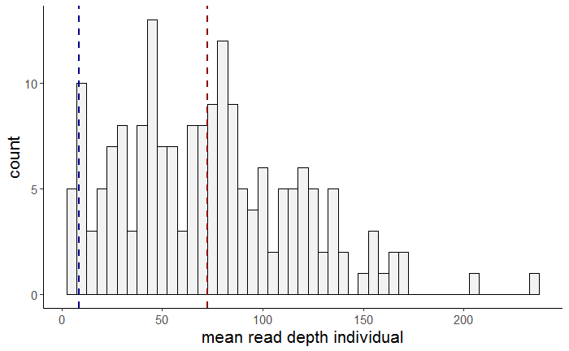

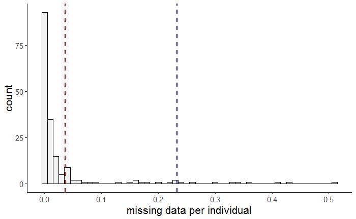

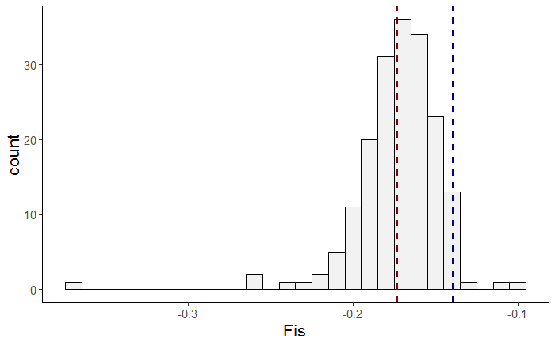

#### Filter 15: Missing data

Set final cut-off for genotype call rate to > 90%.

```
vcftools --vcf FamA.F13.recode.vcf --out FamA.F15a --max-missing 0.9 --recode --recode-INFO-all
vcftools --vcf FamA.F15a.recode.vcf --out FamA.F15a --missing-indv
```

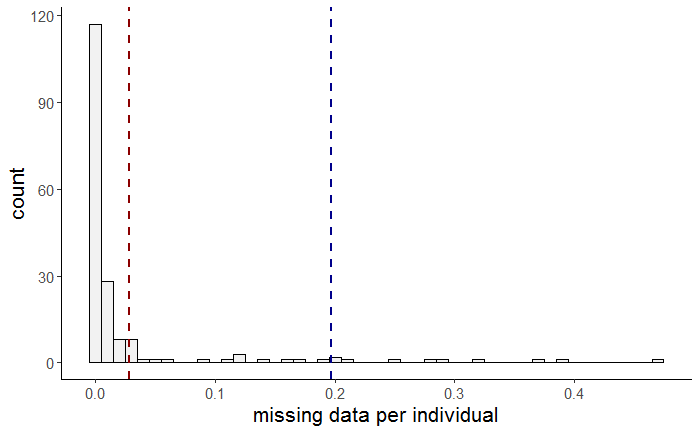

Set final cut-off for allowable missing data per individual to < 50%.

```
mawk -v x=0.5 '$5 > x' FamA.F15a.imiss | cut -f1 > lowDP.indv
vcftools --vcf FamA.F15a.recode.vcf --out FamA.SNP --remove lowDP.indv --recode --recode-INFO-all

vcftools --vcf FamA.SNP.recode.vcf --out FamA.SNP --missing-indv
vcftools --vcf FamA.SNP.recode.vcf --out FamA.SNP --missing-site
vcftools --vcf FamA.SNP.recode.vcf --out FamA.SNP --site-mean-depth
vcftools --vcf FamA.SNP.recode.vcf --out FamA.SNP --depth
vcftools --vcf FamA.SNP.recode.vcf --out FamA.SNP --het
vcftools --vcf FamA.SNP.recode.vcf --out FamA.SNP --hardy
vcftools --vcf FamA.SNP.recode.vcf --out FamA.SNP --freq
```

## Family B

For *Family-B* HiSeq data mapped to MiSeq reference generated using all individuals in library.

### Prepare SNP data set for filtering

dDocent uses FreeBayes to call SNPs and write a VCF-file `TotalRawSNPs.vcf`. This data set was filtered to remove low quality and artefactual SNP sites, paralogs and low quality individuals based on levels of missing data, minimum/maximum read depth, genotype call rate, and minor allele frequencies. Contigs may contain more than one SNP; the script `rad_haplotyper.pl` was used to create haplotypes for each locus.

Generate a list of all individuals included in the SNP data set called by FreeBayes in the dDocent pipeline.

```
cd /home/soleary/FLOUNDER/SEQUENCES/SFL-FamB
vcfsamplenames TotalRawSNPs.vcf > Ind_RAW
```

Use `VCFtools` to create stats files for depth, missing data, heterozygosity and site quality for the raw data.

```
vcftools --vcf TotalRawSNPs.vcf --out FamB_raw --depth
vcftools --vcf TotalRawSNPs.vcf --out FamB_raw --site-mean-depth
vcftools --vcf TotalRawSNPs.vcf --out FamB_raw --site-quality
vcftools --vcf TotalRawSNPs.vcf --out FamB_raw --missing-indv
vcftools --vcf TotalRawSNPs.vcf --out FamB_raw --missing-site
vcftools --vcf TotalRawSNPs.vcf --out FamB_raw --het
```

Identify low quality individuals by comparing levels of missing data and read depth.

```r
ind_stats_raw <- read.ind.stats(dir = "data/VCF", vcf = "FamB_RAW") %>%
  separate(INDV, into = c("SP", "LIB", "SAMPLE_ID"), sep = "_", remove = FALSE)
```

```
There were 11 warnings (use warnings() to see them)
```

Mean read depth per individual across all SNP sites, the mean mean depth across all SNP sites is 17.7704659, the 5th % quantile is 4.644428; the mode is 21.6999:

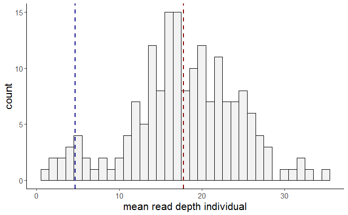

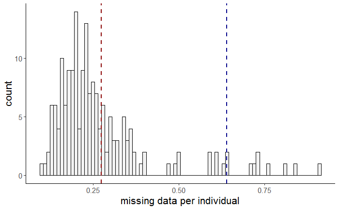

Heterozygosity per individual across all SNP sites; the mean values for Fis is 0.1992137, the 95th % quantile is 0.342944 and the 5th % quantile is 0.004105:

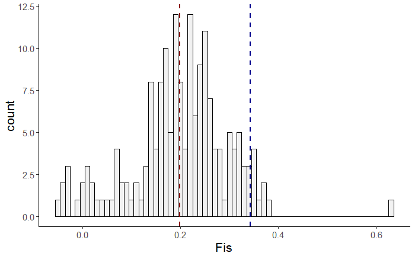

### Choose threshold values for quality score, coverage, missing data, minor alleles

#### Filter 0: Sequence quality

The QUAL column of a VCF file is a phred based score indicating the probability that the variant shown in the ALT column is wrong. Given the Phred quality score (Q), and the probability that a base is incorrectly called (P), Q = -10(Log10P).

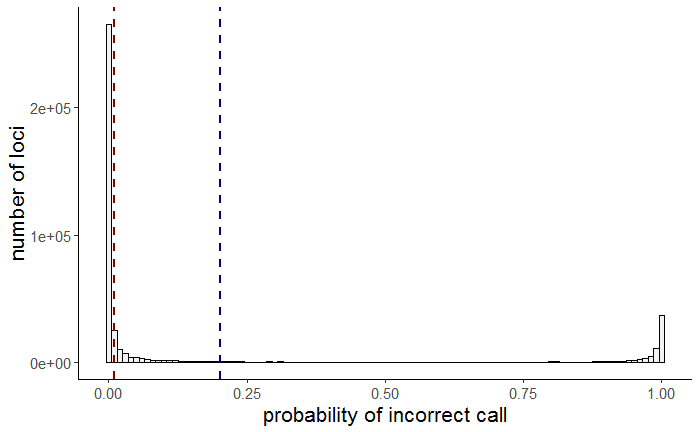

A quality score of 20 indicates, a 1 in 100 chance that the SNP site has been called incorrectly (i.e. 99% probability that correct call).

| QUAL > 20 | n |
| --- | --- |
| FALSE | 165291 |
| TRUE | 281853 |

Filter loci below minimum quality of 20:

```
vcftools --vcf TotalRawSNPs.vcf --out FamB.F0 --minQ 20 --recode --recode-INFO-all
```

#### Filter 1: genotype call rate & minimum minor allele count

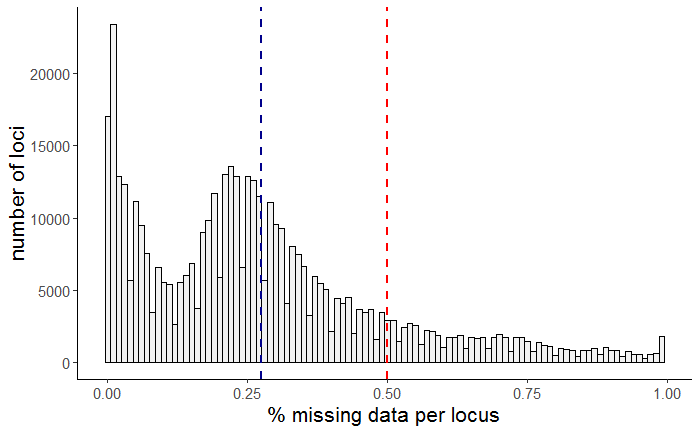

| MISS_FamB_raw > 0.5 | n |
| --- | --- |
| FALSE | 381324 |
| TRUE | 65820 |

Filter loci with minor allele count < 3 and genotype call rate < 0.5

```
vcftools --vcf FamB.F0.recode.vcf --out FamB.F1a --mac 3 --recode --recode-INFO-all
```

retain 194,600 of 281,853 loci.

```
vcftools --vcf FamB.F1a.recode.vcf --out FamB.F1b --max-missing 0.5 --recode --recode-INFO-all
```

retain 169,426 of 194,600 loci.

#### Filter 2: minimum depth per genotype

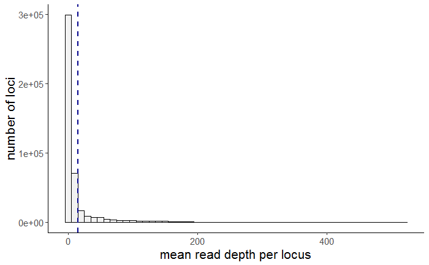

Code loci with less than 5 reads per locus per individual as missing.

```
vcftools --vcf FamB.F1b.recode.vcf --out FamB.F2a --minDP 5 --recode --recode-INFO-all
```

Remove flagged loci.

```
vcftools --vcf FamB.F2a.recode.vcf --out FamB.F2  --max-missing 0.5 --recode --recode-INFO-all
```

Remaining loci 47,027.

Query individual and site stats:

```
vcftools --vcf FamB.F2.recode.vcf --out FamB.F2 --depth
vcftools --vcf FamB.F2.recode.vcf --out FamB.F2 --site-mean-depth
vcftools --vcf FamB.F2.recode.vcf --out FamB.F2 --site-quality
vcftools --vcf FamB.F2.recode.vcf --out FamB.F2 --missing-site
vcftools --vcf FamB.F2.recode.vcf --out FamB.F2 --missing-indv
vcftools --vcf FamB.F2.recode.vcf --out FamB.F2 --het
```

Assess individual quality by comparing levels of missing data and read depth.

Mean read depth per individual across all SNP sites (mode = 67.4664).

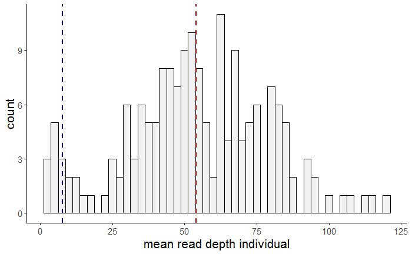

```r
ggplot(ind_stats_F2, aes(x = MEAN_DEPTH_FamB.F2)) +
  geom_histogram(binwidth = 2.5, color = "black", fill = "grey95") +
  geom_vline(aes(xintercept = mean(MEAN_DEPTH_FamB.F2, na.rm = TRUE)),
                 color = "darkred", linetype = "dashed", size = 1) +
  geom_vline(aes(xintercept = quantile(MEAN_DEPTH_FamB.F2, .05)),
                 color = "darkblue", linetype = "dashed", size = 1) +
  labs(x = "mean read depth individual") +
  theme_standard
```

Frequency of missing data per individual across all SNP sites after removing poor quality loci:

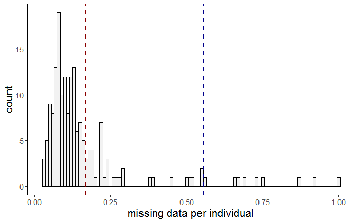

```r
ggplot(ind_stats_F2, aes(x = MISS_FamB.F2)) +
  geom_histogram(binwidth = .01, color = "black", fill = "grey95") +
  geom_vline(aes(xintercept = mean(MISS_FamB.F2, na.rm = TRUE)),
                 color = "darkred", linetype = "dashed", size = 1) +
  geom_vline(aes(xintercept = quantile(MISS_FamB.F2, .95)),
                 color = "darkblue", linetype = "dashed", size = 1) +
  labs(x = "missing data per individual") +
  theme_standard
```

Heterozygosity per individual across all SNP sites after removing poor quality loci:

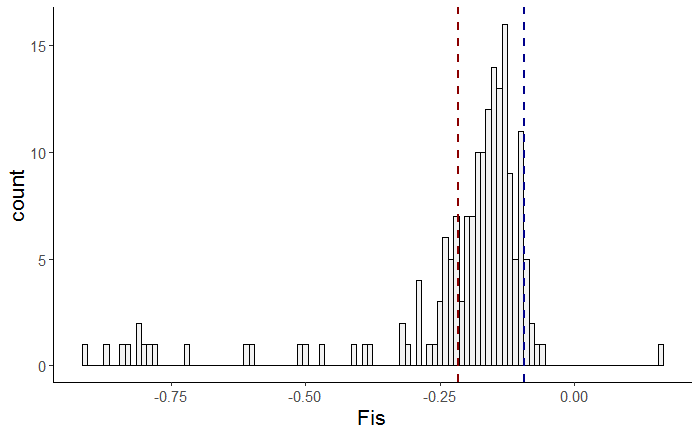

```r
ggplot(ind_stats_F2, aes(x = Fis_FamB.F2)) +
  geom_histogram(binwidth = .01, color = "black", fill = "grey95") +
  geom_vline(aes(xintercept = mean(Fis_FamB.F2, na.rm = TRUE)),
                 color = "darkred", linetype = "dashed", size = 1) +
  geom_vline(aes(xintercept = quantile(Fis_FamB.F2, .95)),
                 color = "darkblue", linetype = "dashed", size = 1) +
  labs(x = "Fis") +
  theme_standard
```

Sequence quality (likelihood of correct variant call) after removing poor quality loci:

```r
site_qual <- read.table("data/VCF/FamB.F2.lqual",
                        header = TRUE, stringsAsFactors = FALSE) %>%
  mutate(PROB = 10^(-QUAL/10))
quantile(site_qual$QUAL)
```

```
         0%         25%         50%         75%        100%
2.00009e+01 9.39194e+01 2.52502e+04 1.46996e+05 2.30737e+06
```